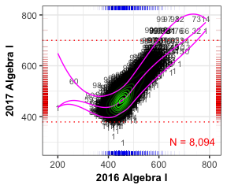

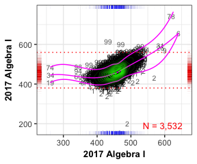

**Fig. C.7:** Conditional distribution(s) of current and prior scale scores: Geometry.

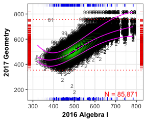

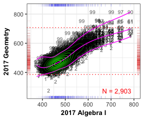

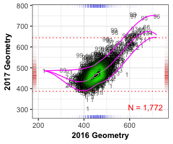

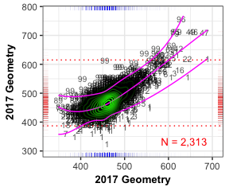

**Fig. C.8:** Conditional distribution(s) of current and prior scale scores: Coordinate Algebra.

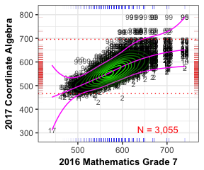

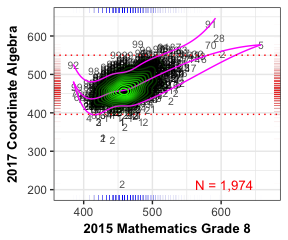

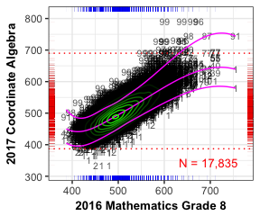

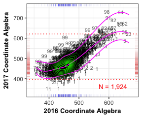

**Fig. C.9:** Conditional distribution(s) of current and prior scale scores: Analytic Geometry.

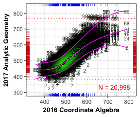

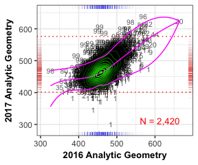

# 3 SGP Ranges for the Highest and Lowest Achieving Students

In order to isolate the impact of assessment ceilings/floors on student growth percentile (SGP) calculations, the following section provides box plots of the distribution of SGPs for the highest and lowest achieving students. We are specifically interested in the growth percentiles for students scoring at the highest/lowest obtainable scale score (HOSS/LOSS - i.e. the test ceiling/floor) on the current year test. However, in order to assure that an adequate number of students are included, the first set of plots uses, at a *minimum*, the highest/lowest 25 scores. These plots are provided as a starting point since this roughly corresponds to the number of students in the top and bottom rows of the table included in the SGP model goodness of fit plots. All students with a score in these students’ range of scores are included. Consequently, the number of students in each box plot may be greater than 25 (the exact number is shown at the margins in red text).

The second set of box plots isolate *only* those students scoring the HOSS/LOSS. These plots may then incorporate a varying number of students depending on the prevalence of a ceiling/floor in the current year. The Ranked SIMEX measurement error corrected SGP is Georgia’s official growth metric, and these values are used exclusively in this report.

The box plots provide several descriptive statistics. The dark line within the box marks the *median* SGP, while the ends (“hinges”) of the boxes correspond to the first and third quartiles (the 25<sup>th</sup> and 75<sup>th</sup> percentiles). The upper whisker extends from the hinge to the highest value that is within 1.5 $×$ IQR of the hinge, where IQR is the inter-quartile range, or distance between the first and third quartiles. The lower whisker extends from the hinge to the lowest value within 1.5 $×$ IQR of the hinge. Data beyond the end of the whiskers are outliers and plotted as individual points. Evidence of a *lack* of either a ceiling or floor effect would be to have all high achieving students with SGPs near 99 and all low achieving students with SGPs near 1. That is, the desired visual evidence is a solid line at SGP = 99/1.

## 3.1 EOG Content Areas

**Fig. C.10:** EOG SGP distributions for highest and lowest 25+ scale scores by content area and grade level.

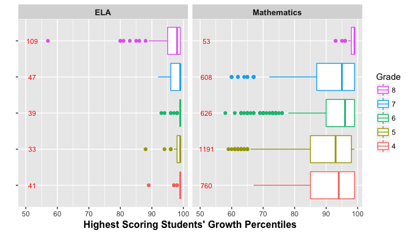

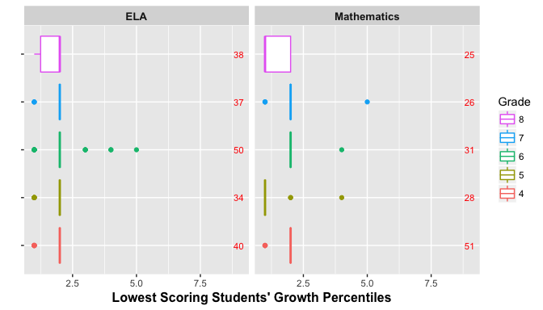

**Fig. C.11:** EOG SGP distributions for the HOSS and LOSS scores by content area and grade level.

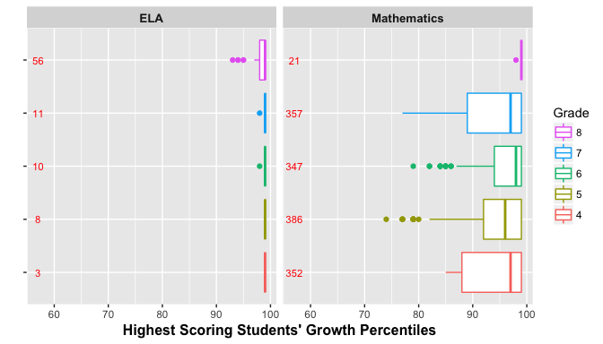

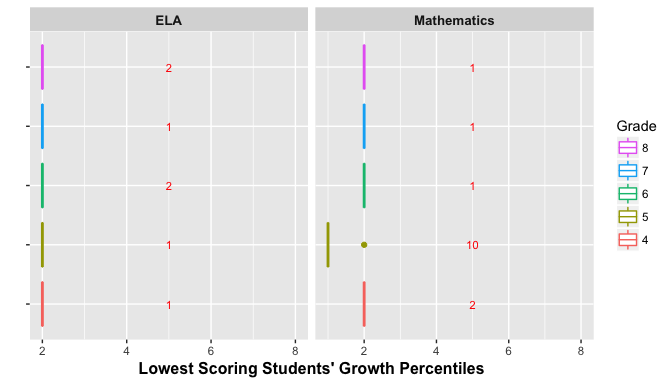

## 3.2 EOC Subjects

The end-of-course subject results are shown here *only for students scoring exactly the HOSS and LOSS* respectively. There are several subjects for which potential ceiling effects are evident. All EOC subjects are disaggregated further by the most recent prior test included in each analyses in order to adequately address any concerns.

**Fig. C.12:** EOC SGP distributions for the HOSS and LOSS scores by content area.

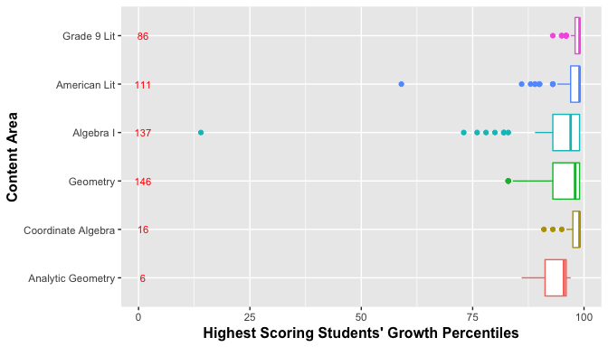

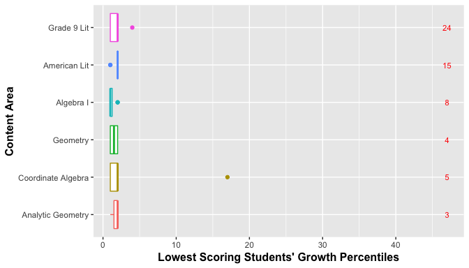

The EOC subject box plots can be disaggregated further by the most recent prior to reflect their constituent norm groups more closely. The following box plots disaggregate each EOC subject by norm groups. A pattern emerges in these plots suggesting that the course repeater and those that included skipped years have potentially problematic SGP estimates for a handful of students.

**Fig. C.13:** EOC SGP distributions for the HOSS and LOSS scores by norm group: 9<sup>th</sup> Grade Literature.

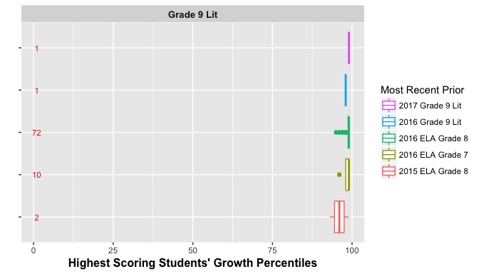

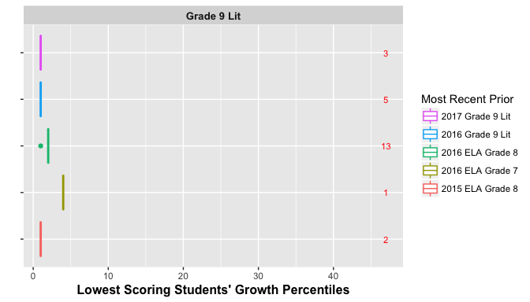

**Fig. C.14:** EOC SGP distributions for the HOSS and LOSS scores by norm group: American Literature.

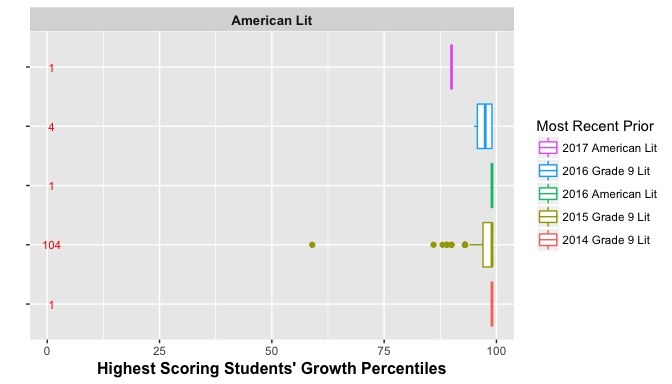

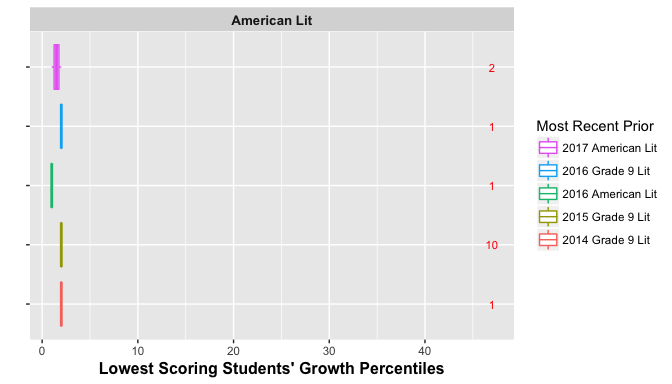

The plots for the Algebra I course repeater (2016) progression is notable. This progression can also be seen in Figure C.6 above. Here the student who scored the HOSS consecutively has an unexpectedly low SGP of 14. Another student of interest in in this analysis scored the HOSS in 2017, and slightly lower in 2016. This student’s SGP was estimated to be 73; substantially higher, but still lower than one might expect. These students are outliers in the data and it is not surprising that the SGP estimates of their growth are questionable.

**Fig. C.15:** EOC SGP distributions for the HOSS and LOSS scores by norm group: Algebra I.

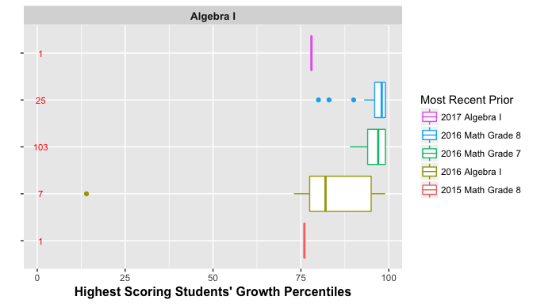

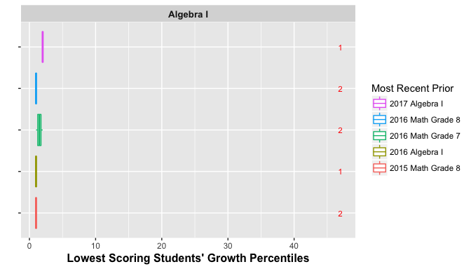

**Fig. C.16:** EOC SGP distributions for the HOSS and LOSS scores by norm group: Geometry.

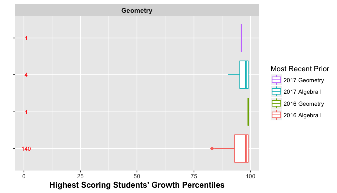

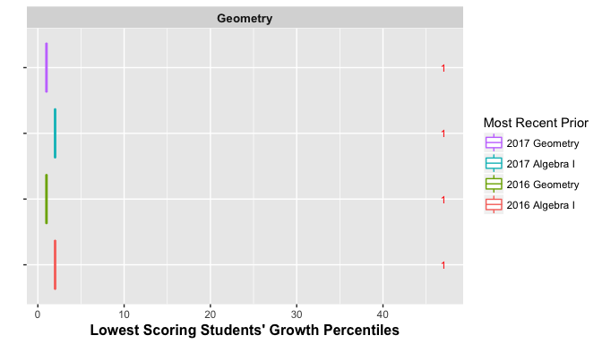

**Fig. C.17:** EOC SGP distributions for the HOSS and LOSS scores by norm group: Coordinate Algebra.

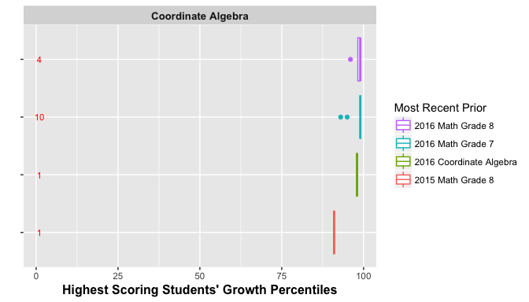

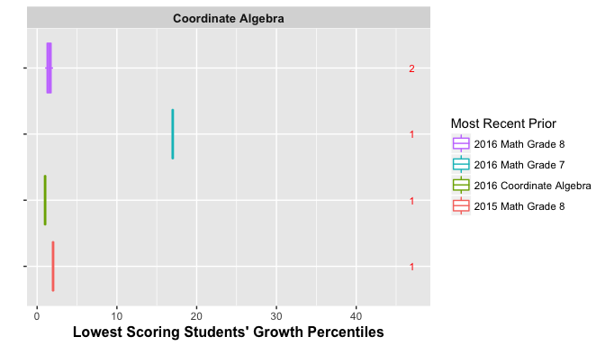

**Fig. C.18:** EOC SGP distributions for the HOSS and LOSS scores by norm group: Analytic Geometry.

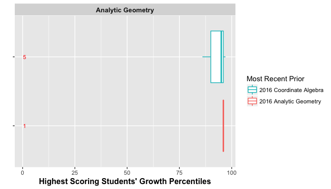

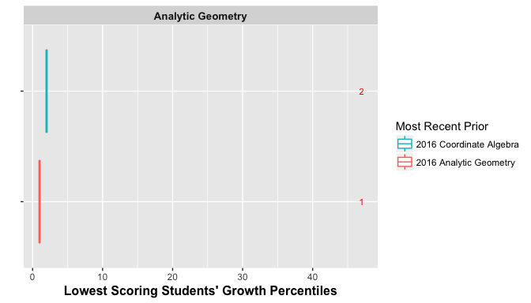

# 4 Discussion

Overall there is little evidence of floor or ceiling effects in the 2017 Georgia Milestones SGP analyses. Some scores for EOC test repeaters and skip year progressions suggest that a small number of minor problems may exist that could require changes. When ceiling or floor effects are encountered, there are several ways in which they can be “corrected” manually or analytically. These include (but not limited to):

1. Convert all students scoring at the HOSS (LOSS) to 99 (1). Georgia has used this manual correction beginning in 2016.
2. Run SGP analyses with more granular scores. For example, many tests that use Item Response Theory (IRT) to analyse test results provide scaled scores that enforce an artificial ceiling (floor), but also have more granular achievement scores available (IRT *θ* estimates).
3. Leave the results without a correction.
[^1]: Ranked SIMEX measurement error corrected SGPs are the “official” SGP in Georgia, and are used exclusively in this report.
[^2]: Note that many SGPs are estimated using more than one prior score, and therefore plots may show SGP results from multiple analyses and/or varying SGPs for identical score combinations.
[^3]: Produced using quantile regression similar to, but not the same as, that used in calculation of the SGPs.